# Stage III NSCLC Survival Prediction

DA5030

Julissa Zelaya Portillo

Fall 2023

## Business Understanding

A physician’s value is in accurately identifying and diagnosing patients based on reported metrics. In the case of 548 patients, data is obtained from the following clinical investigation to build a predictive model: “A Validated Prediction Model for Overall Survival From Stage III Non-Small Cell Lung Cancer: Toward Survival Prediction for Individual Patients” (Oberije, et al., 2015). The original study provides a cox regression model based on 22 clinical variables.

It is the aim of this markdown to implement various classification machine learning models. Unlike the original model, this does not include a time component, but may provide useful insight on model comparisons. More importantly, this may also provide an additional perspective on whether a patient is marked for near-death or survival.

## Data Understanding

### Data Exploration

The original NSCLC data is formatted as a `.csv` file and is acquired through its open-source URL address.

```r
url <- ("https://www.cancerdata.org/system/files/publications/Stage3_anonymized.csv")
cancer <- read.csv(url, sep = ";") # source CSV is not comma-separated
# Check the structure of the data frame
str(cancer)
```

```
## 'data.frame':    548 obs. of  24 variables:
##  $ study_id          : int  1 2 3 4 5 6 7 8 9 10 ...
##  $ gender            : int  1 2 1 2 1 1 2 2 1 2 ...
##  $ age               : chr  "63,1567419575633" "66,3052703627652" "58,1984941820671" "63,7809719370294" ...
##  $ who3g             : int  2 2 1 2 1 2 2 1 2 2 ...
##  $ bmi               : chr  "22,9938271604938" "28,515625" "25,1278305332359" "28,7267877295578" ...
##  $ fev1pc_t0         : chr  "82" "62" "95" "73" ...
##  $ dumsmok2          : int  2 2 2 2 2 2 2 2 2 2 ...
##  $ t_ct_loc          : int  6 1 4 6 6 1 6 NA 7 2 ...
##  $ hist4g            : int  4 1 1 2 4 4 3 1 1 3 ...
##  $ countpet_all6g    : int  4 4 1 6 3 3 3 2 1 1 ...
##  $ countpet_mediast6g: int  4 3 1 5 3 2 2 2 1 1 ...
##  $ tstage            : int  4 4 4 NA 2 NA 2 2 4 4 ...
##  $ nstage            : int  4 3 1 4 3 3 3 3 1 1 ...
##  $ stage             : int  2 2 2 2 1 1 1 1 2 2 ...
##  $ timing            : int  3 3 3 3 3 3 3 2 3 3 ...
##  $ group             : int  4 4 4 4 4 4 4 2 4 4 ...
##  $ yearrt            : int  2008 2010 2008 2007 2008 2006 2009 2007 2008 2008 ...
##  $ eqd2              : chr  "53,125" "55,125" "65,125" "63,125" ...
##  $ ott               : int  28 32 32 36 36 35 37 22 38 39 ...
##  $ gtv1              : chr  "192,86" "154,93" "85,07" "98,17" ...
##  $ tumorload_total   : chr  "214,08" "169,9" "85,07" "120,51" ...
##  $ survmonth         : chr  "16,9199178644764" "5,12525667351129" "57,96" "7,42505133470226" ...
##  $ survyear          : chr  "1,40999315537303" ",427104722792608" "4,83" ",618754277891855" ...
##  $ deadstat          : int  1 1 0 1 1 1 0 1 0 1 ...
```

The structure of the original data shows a data frame with the expected 548 patients. The additional feature for `study_id` will need to be removed to focus on the 22 clinical variables. It also becomes known that there are missing values within the data that will need to be addressed later on. The immediate concern is that there are features that use commas instead of decimals. These features incorrectly have a character data type instead of numeric. This formatting issue will need to be addressed before exploratory visualizations can be performed.

Commas are replaced with periods in the eight listed character features. This is to accurately represent decimals (floats). All integers are then converted to factors to distinguish the presence of categorical features.

```r
# Remove first column as ID is not necessary
cancer <- cancer[, -1]
# Remove duplicate feature as survival month equals the survival year
cancer$survmonth <- NULL

# List character features data types that should be numeric
chr_to_numeric <- c("age", "bmi", "fev1pc_t0", "eqd2", "ott", "gtv1",
                    "tumorload_total", "survyear")

# Replace commas with periods
cancer <- cancer %>%
  mutate(across(all_of(chr_to_numeric), ~gsub(",", ".", .)))

# Convert the specified features to numeric
cancer <- cancer %>%
  mutate(across(all_of(chr_to_numeric), as.numeric))

# Identify integer columns
integer_cols <- sapply(cancer, is.integer)

# Factorize integer variables
cancer[, integer_cols] <- lapply(cancer[, integer_cols], as.factor)
```

All incorrect data types are now numeric. It is noted that categorical features have label encoding applied. These features are labeled and factored to make interpretation of these variables easier later on.

### Detection of Outliers for Continuous Features

Based on the output below, is evident that there are significant outliers–especially from the two tumor related variables. The question is whether this is due to the exponential growth that occurs in tumor cells.

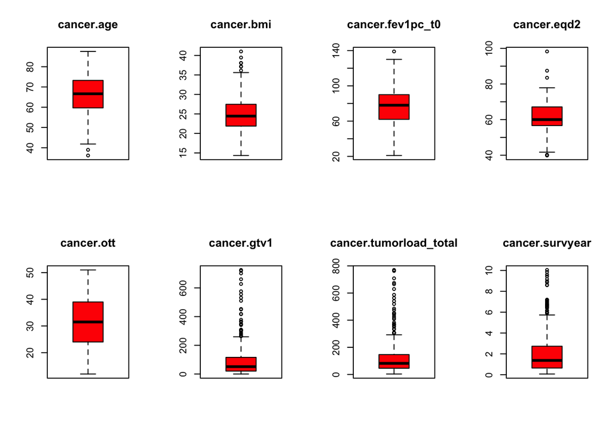

```r
# Create a data frame with continuous features from `cancer` data frame
cancer_continuous <- data.frame(cancer$age, cancer$bmi, cancer$fev1pc_t0,
                                cancer$eqd2,cancer$ott, cancer$gtv1,
                                cancer$tumorload_total, cancer$survyear)

# Specify window for eight variables
par(mfrow = c(2, 4))

# Create box plots for each continuous variable
for (variable in colnames(cancer_continuous)) {
  boxplot(cancer_continuous[[variable]], main = variable, col = "red")
}
```

A z-score method is implemented to better identify the extent of how many outliers there are. A non-conservative approach is taken considering that the nature of cancer cells may cause unexpected extremes.

```r
# Function to detect outliers using Z-scores
detect_outliers <- function(x, threshold = 3) {
  x_no_na <- na.omit(x)  # Remove missing values
  z_scores <- scale(x_no_na)
  outliers <- abs(z_scores) > threshold
  return(sum(outliers))
}

# Apply the function to each variable
outlier_counts <- sapply(cancer_continuous, detect_outliers)

# Display the number of outliers for each variable
print(outlier_counts)
```

```
##             cancer.age             cancer.bmi       cancer.fev1pc_t0
##                      1                      4                      0
##            cancer.eqd2             cancer.ott            cancer.gtv1
##                      3                      0                     13
## cancer.tumorload_total        cancer.survyear
##                     12                      9
```

In addition to the previously noted outliers, there are outliers including survival years and BMI. It is hard to determine the value of these outlier data point so this information is noted and will be considered during data cleaning and shaping.

### Evaluation of Distribution

Further insight of the data distribution can be gained from density plots.

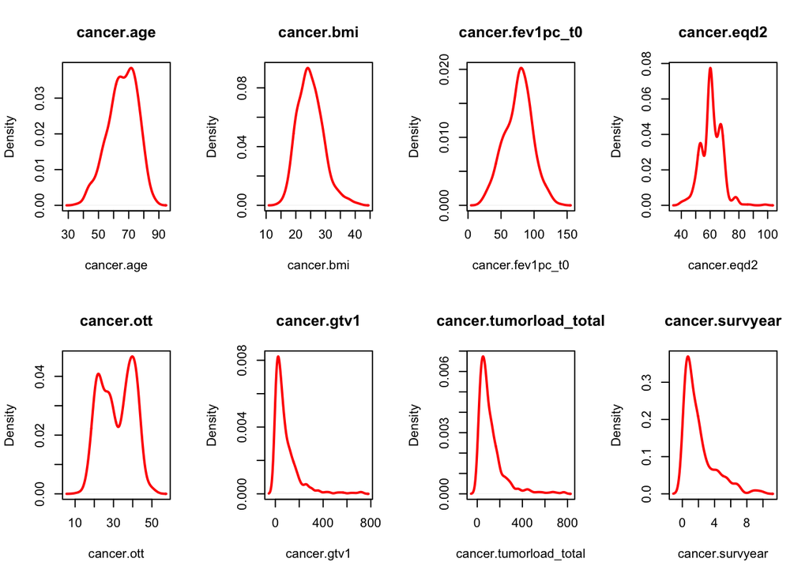

```r
# Show all plots together
par(mfrow = c(2, 4))

# Create density plots for subset of continuous features
for (i in 1:8) {
  # Calculate density
  dens <- density(cancer_continuous[, i], na.rm = TRUE)

  # Plot density
  plot(dens, main = names(cancer_continuous)[i],
       xlab = names(cancer_continuous)[i], col = "red", lwd = 2)
}
```

```r
# Function to perform Shapiro-Wilk test
shapiro_function <- function(x) {
  result <- shapiro.test(x)
  return(c(result$statistic, "P Value" = result$p.value)) # return p-value
}

# Apply the function to each continuous variable
shapiro_results <- sapply(cancer_continuous, shapiro_function)

# Create a data frame for display
shapiro_df <- data.frame(t(shapiro_results))
shapiro_df
```

|  | W | P.Value |
| --- | --- | --- |
| cancer.age | 0.9854021 | 2.664174e-05 |
| cancer.bmi | 0.9786985 | 2.883216e-05 |
| cancer.fev1pc_t0 | 0.9944815 | 8.345135e-02 |
| cancer.eqd2 | 0.9607110 | 6.359632e-11 |
| cancer.ott | 0.9430076 | 1.165209e-13 |
| cancer.gtv1 | 0.7039418 | 1.610785e-29 |
| cancer.tumorload_total | 0.7445228 | 3.206585e-27 |
| cancer.survyear | 0.8256353 | 5.774455e-24 |

A p-value less than the chosen significance level (0.05), indicates strong evidence to reject the null hypothesis. Each p-value shown above has a low p-value meaning all these features do not follow a normal distribution. This supports the visually skewed data plot from the output above. The only exception is the `fev1pc_t0` (Forced Expiratory Volume). Regardless, it is understood that feature transformations will need to be made.

All continuous features have now been evaluated for outliers and overall data distribution. It is now important to have an understanding of the distribution of the categorical features.

The frequency of each level within each categorical feature is shown in the frequency table below.

```r
# Specify the categorical variables
cancer_categorical <- c("gender", "who3g", "dumsmok2", "t_ct_loc", "hist4g",
                        "countpet_all6g", "countpet_mediast6g",
                        "tstage", "nstage", "stage", "timing",
                        "group", "yearrt")

# Create and print percentage tables for each categorical variable
for (variable in cancer_categorical) {
  cat("Percentage Distribution of", variable, ":\n")
  print(prop.table(table(cancer[[variable]])) * 100)
  cat("\n")
}
```

```
## Percentage Distribution of gender :
##
##        1        2
## 69.16058 30.83942
##
## Percentage Distribution of who3g :
##
##        1        2        3
## 35.42435 52.95203 11.62362
##
## Percentage Distribution of dumsmok2 :
##
##        1        2
## 60.15779 39.84221
##
## Percentage Distribution of t_ct_loc :
##
##          1          2          3          4          5          6          7
## 14.6387833  4.9429658  2.0912548 36.6920152  8.7452471 26.8060837  3.4220532
##          8         10         11         13         14         15         17
##  0.7604563  0.1901141  0.1901141  0.1901141  0.1901141  0.3802281  0.3802281
##         18
##  0.3802281
##
## Percentage Distribution of hist4g :
##
##        1        2        3        4
## 31.06061 15.34091 35.98485 17.61364
##
## Percentage Distribution of countpet_all6g :
##
##        1        2        3        4        5        6
## 20.07722 20.65637 21.81467 13.32046 10.42471 13.70656
##
## Percentage Distribution of countpet_mediast6g :
##
##         1         2         3         4         5         6
## 23.745174 30.115830 17.567568 11.003861  9.459459  8.108108
##
## Percentage Distribution of tstage :
```

[output cut: 15 more lines]

```
##
##        1        2        3
## 12.04380 51.09489 36.86131
##
## Percentage Distribution of group :
##
##         1         2         3         4
## 12.043796  8.576642 42.518248 36.861314
##
## Percentage Distribution of yearrt :
##
##      2002      2003      2004      2005      2006      2007      2008      2009
##  5.474453 11.861314 10.401460  9.124088 11.861314  9.854015 12.226277 11.678832
##      2010      2011
##  6.934307 10.583942
```

Two features that initially seem to have skewed data are based on gender and smoker status (`dumsmok2`). This clinical data is acquired from 70% of males and 60% of non-smokers.

A frequency table is now obtained for the target feature.

```r
# Rename 0 for "Alive" and 1 for "Dead"
cancer$deadstat <- factor(cancer$deadstat, levels = c(0, 1),
                        labels = c("Alive", "Dead"))

# Display percentage of each patient outcome
round(prop.table(table(cancer$deadstat)) * 100, digits = 0)
```

```
##
## Alive  Dead
##    17    83
```

83% of outcomes classify death. This is very important to note as this majority may introduce a bias when training a classification model. In terms of evaluation metrics, accuracy alone will not be sufficient. Precision, recall, F1 score, and/or area under the ROC curve will need to be used later on.

### Correlation, Collinearity, and Chi-Squared Analysis

It is now important to determine the effect of collinearity. This is the correlation between predictor variables that would create what is considered “noise” in a data model. The scatterplot matrix created below presents a visual interpretation of this.

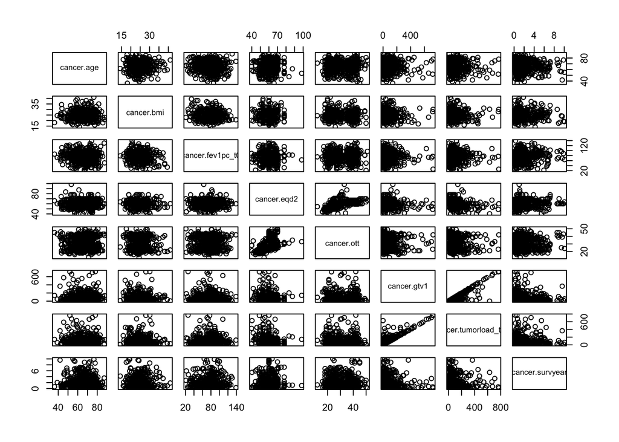

```r
# Create scatterplot matrix of continuous features
pairs(cancer_continuous)
```

A linear relationship is noted between gross tumor volume and the total tumor load. This is expected because of the overlapping nature of these features.

These relationships can be confirmed through a matrix of Pearson’s correlation values. This would highlight individual relationships or suggest collinearity between any continuous variables.

```r
# Calculate the correlation matrix, skipping missing values
cor_matrix <- cor(cancer_continuous, use = "complete.obs", method = "pearson")
cor_matrix
```

```
##                          cancer.age   cancer.bmi cancer.fev1pc_t0  cancer.eqd2
## cancer.age              1.000000000  0.025727790      -0.16625129 -0.009714724
## cancer.bmi              0.025727790  1.000000000      -0.11647987 -0.058388976
## cancer.fev1pc_t0       -0.166251292 -0.116479866       1.00000000 -0.010652526
## cancer.eqd2            -0.009714724 -0.058388976      -0.01065253  1.000000000
## cancer.ott             -0.073497369 -0.010357500       0.02932082  0.453099121
## cancer.gtv1            -0.034132834 -0.009987164      -0.07293494 -0.199037735
## cancer.tumorload_total -0.088489211  0.008961897      -0.04226182 -0.349137153
## cancer.survyear        -0.100476918 -0.040667975       0.06369346  0.091110481
##                         cancer.ott  cancer.gtv1 cancer.tumorload_total
## cancer.age             -0.07349737 -0.034132834           -0.088489211
## cancer.bmi             -0.01035750 -0.009987164            0.008961897
## cancer.fev1pc_t0        0.02932082 -0.072934943           -0.042261815
## cancer.eqd2             0.45309912 -0.199037735           -0.349137153
## cancer.ott              1.00000000 -0.048993083           -0.094595626
## cancer.gtv1            -0.04899308  1.000000000            0.848459386
## cancer.tumorload_total -0.09459563  0.848459386            1.000000000
## cancer.survyear        -0.03041371 -0.163074251           -0.190357863
##                        cancer.survyear
## cancer.age                 -0.10047692
## cancer.bmi                 -0.04066798
## cancer.fev1pc_t0            0.06369346
## cancer.eqd2                 0.09111048
## cancer.ott                 -0.03041371
## cancer.gtv1                -0.16307425
## cancer.tumorload_total     -0.19035786
## cancer.survyear             1.00000000
```

The correlation matrix confirms a strong relationship between gross tumor volume and tumor load total with a value of 0.85. This will need to be addressed during data preparation as this could introduce noise into our model.

As the correlation matrix accounts for continuous variables, a chi-squared analysis will be performed for the remaining categorical variables.

```r
# Perform the chi-squared test on the categorical variables
chi_results <- lapply(cancer[, cancer_categorical], function(x) {
  chisq.test(table(x))
})
chi_results
```

```
## $gender
##
##  Chi-squared test for given probabilities
##
## data:  table(x)
## X-squared = 80.474, df = 1, p-value < 2.2e-16
##
##
## $who3g
##
##  Chi-squared test for given probabilities
##
## data:  table(x)
## X-squared = 139.93, df = 2, p-value < 2.2e-16
##
##
## $dumsmok2
##
##  Chi-squared test for given probabilities
##
## data:  table(x)
## X-squared = 20.925, df = 1, p-value = 4.776e-06
##
##
## $t_ct_loc
##
##  Chi-squared test for given probabilities
##
## data:  table(x)
## X-squared = 1365.5, df = 14, p-value < 2.2e-16
##
##
## $hist4g
##
##  Chi-squared test for given probabilities
##
## data:  table(x)
## X-squared = 64.47, df = 3, p-value = 6.513e-14
##
##
```

[output cut: 47 more lines]

```
##
## $group
##
##  Chi-squared test for given probabilities
##
## data:  table(x)
## X-squared = 194.03, df = 3, p-value < 2.2e-16
##
##
## $yearrt
##
##  Chi-squared test for given probabilities
##
## data:  table(x)
## X-squared = 25.139, df = 9, p-value = 0.002822
```

## Data Preparation

With an understanding of the NSCLC cancer data set, data cleaning and shaping will be performed for better model constructions.This encompasses the imputation of missing data, normalization/standardization, dummy codes, feature transformation, PCA, and feature engineering.

### Identification of Missing Values

It is necessary to first determine the extent of missing values in the working data set. The count of missing values are presented by feature to compare to the overall 548 observations. For instance, the BMI feature has 179 missing values that corresponds to 33% of the feature data being missing.

```r
# Identify missing values in the entire data set per feature
missing_values <- sapply(cancer, function(x) sum(is.na(x)))
missing_values
```

```
##             gender                age              who3g                bmi
##                  0                  0                  6                179
##          fev1pc_t0           dumsmok2           t_ct_loc             hist4g
##                 71                 41                 22                 20
##     countpet_all6g countpet_mediast6g             tstage             nstage
##                 30                 30                 26                  4
##              stage             timing              group             yearrt
##                  0                  0                  0                  0
##               eqd2                ott               gtv1    tumorload_total
##                  0                  0                 17                 41
##           survyear           deadstat
##                  0                  0
```

### Data Imputation of Missing Data

It is a common method to input missing data with the mean, median, or mode of that value’s feature, but there are a considerate amount of missing values here. A more sophisticated method of imputing randomly missing data is through the use of the `mice` package. The `mice` package will use Predictive Mean Matching to fill in missing values by drawing observations from other values close-by and making its own prediction. This will retain the original distribution of the data set.

### Feature Engineering: New Derived Features

```r
# Rewrite is done to preserve order of columns
lung$gtv1 <- lung$gtv1 / lung$tumorload_total

# Rename the `gtv1` column to `gtv1_total`
lung <- rename(lung, gtv1_total = gtv1)

# Remove original `tumorload_total` to avoid duplicates
lung <- subset(lung, select = -c(tumorload_total))
```

### Normalization/Standardization of Data

When comparing normalization versus standardization of data, it is important to consider the distribution of the working data set and the desired machine learning models. While normalization is highly affected by outliers, the use of standardization would create many negative values. This is because the original data has a large range in values. This is noted by the presence of many outliers and a non-normal distribution.

```r
# Identify numeric columns
lung_numeric <- sapply(lung, is.numeric)

# Min-Max scaling
lung[, lung_numeric] <- scale(lung[, lung_numeric], center = FALSE)
```

### Dummy Codes

Nominal features are identified to appropriately apply dummy encoding. The original data already established label encoding for ordinal features so they will be excluded to preserve their ranking feature. This will be beneficial when working with various models that may need easier distinction between rankings or categorical features.

```r
# Establish categorical, nominal variables that need dummy encoding
lung_categorical_nominal <- c("gender", "dumsmok2", "t_ct_loc", "hist4g")

# Dummy encode nominal variables
lung <- dummy_cols(lung, select_columns = lung_categorical_nominal)

# Remove the original columns after dummy encoding
lung <- lung[, !names(lung) %in% lung_categorical_nominal]
```

The original columns are then removed to avoid duplicates that would cause collinearity.

### Transformation of Features to Adjust Distribution

The working data set has numerical features with high skewness and non-normal distribution (505-508 Distribution). This may be caused by outliers, highly exponential distributions, etc. Therefore, the logarithmic transformation is best.

```r
# Identify numeric columns programmatically
lung_numeric <- names(Filter(is.numeric, lung))

# Apply log transformation to numeric variables
lung[, lung_numeric] <- log(lung[, lung_numeric] + 1)  # Adding 1 to avoid log(0)
```

If we were to now look at the distribution of one of the numerical features, we should now expect to see a more normal distribution.

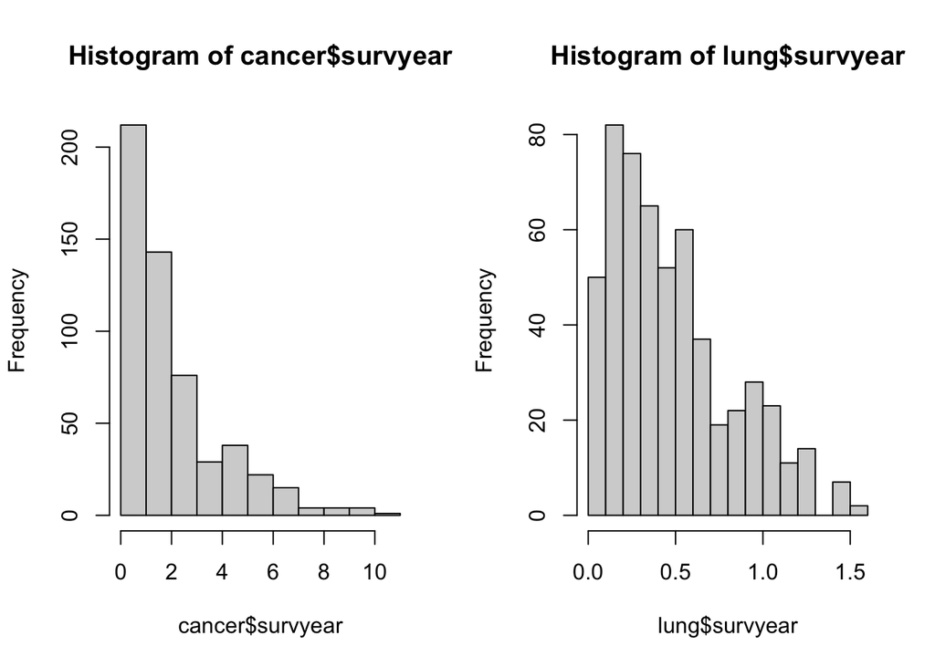

```r
# Show plots side by side
par(mfrow = c(1, 2))

# Compare histogram plots before and after data processing
hist(cancer$survyear)
hist(lung$survyear)
```

### Creation of Training and Validation Subsets

It is important to note that Principal Component Analysis and Feature Engineering will be performed on the working data. Before beginning those processes, the data needs to be split into training and testing data sets. If we were to obtain PCA components of the data at once, the test data would get “leaked” into the training data. This defeats the purpose of building a model that could be generalized to other data sets.

The data set, `lung` will now be split into training and testing data sets.

```r
# Set seed for reproducibility
set.seed(123)

# Perform a random split
splitIndex <- createDataPartition(lung$deadstat, p = 0.8, list = FALSE)
train_data <- lung[splitIndex, ]
test_data <- lung[-splitIndex, ]
```

### Identification of Principal Components (PCA)

Principal Component Analysis reduces the dimension of a data set. Considering the large numbers of features in the `lung` data, this would simplify analysis while preserving variance.

The PCA model is created and the correlation between the features and principal components are shown.

```r
# Create PCA model
pca_model <- prcomp(train_data[, lung_numeric], center = TRUE, scale = TRUE)

# Apply PCA to the training set
train_data_pca <- predict(pca_model, train_data[, lung_numeric])
# Use the same PCA parameters from the training set on the testing set
test_data_pca <- predict(pca_model, test_data[, lung_numeric])

# Identify the principal components
principal_components <- pca_model$rotation

# Display the first few principal components
head(principal_components)
```

```
##                     PC1         PC2         PC3          PC4         PC5
## age        -0.305193200  0.04382987 -0.11230919  0.008995554 -0.22618853
## bmi        -0.084452981  0.04283753 -0.05499343 -0.115060264  0.24448442
## fev1pc_t0   0.035005779  0.10201461  0.18273035  0.202249562  0.01038580
## eqd2       -0.029634406 -0.10538931 -0.30486530  0.489524764  0.05747709
## ott        -0.008689732 -0.12559092 -0.30581529  0.469783314  0.03330326
## gtv1_total -0.149668830 -0.07219297 -0.09749023  0.198153598 -0.31986693
##                    PC6           PC7         PC8         PC9         PC10
## age         0.03918356 -0.0311340255  0.05674338  0.07567585  0.187290792
## bmi         0.25299735  0.1522794177 -0.12678031  0.20868382 -0.003871277
## fev1pc_t0  -0.30958196 -0.2938147791 -0.13100426 -0.28275343  0.135311949
## eqd2        0.12597510  0.0002691043 -0.08620337 -0.19637769 -0.108088617
## ott         0.04567951 -0.0755638968  0.04540161 -0.12229242 -0.071510086
## gtv1_total -0.05969395 -0.0212196040  0.34430330  0.20685760 -0.048128737
##                   PC11         PC12         PC13          PC14        PC15
## age        -0.05122543 -0.280574803  0.117719752  0.1084198246  0.01512311
## bmi         0.25439935 -0.221145330 -0.129304551 -0.0275026139 -0.26236928
## fev1pc_t0  -0.06027720  0.084138599  0.040495990  0.0350142406 -0.15484207
## eqd2        0.02253997 -0.005802513 -0.060342201  0.0919543176  0.04293778
## ott         0.19760047 -0.080963499  0.003807486 -0.1453692695 -0.06098441
## gtv1_total -0.19850534 -0.063220529 -0.120687549  0.0001633618 -0.08451450
##                   PC16         PC17       PC18        PC19         PC20
## age         0.15069346  0.015009599 0.03375959 -0.23454044 -0.182258078
## bmi         0.07751927  0.063390769 0.16094181 -0.05722353  0.177884036
## fev1pc_t0   0.05641534 -0.025121097 0.03522293  0.14834589 -0.208627351
## eqd2        0.06145638  0.005735188 0.03338169  0.17865849 -0.174021854
## ott         0.06496289 -0.022073675 0.08046700  0.20764319 -0.001264659
## gtv1_total -0.08688463  0.072692848 0.04803525 -0.02615098 -0.151009108
##                   PC21        PC22        PC23        PC24        PC25
## age         0.09610169  0.08581956 -0.39715878  0.59536364 -0.21448722
## bmi        -0.39899003  0.40518126  0.01305964  0.12890566  0.39565692
## fev1pc_t0   0.14544324  0.21205801  0.38269677  0.39325436  0.37160132
## eqd2       -0.10561194  0.16661020 -0.09149567 -0.07309441 -0.06779787
## ott        -0.22935309 -0.13131500  0.04650702  0.03672733 -0.22104280
## gtv1_total -0.11080641 -0.36429644 -0.12886314 -0.10984337  0.61333459
##                    PC26          PC27          PC28          PC29          PC30
## age         0.016266471  3.537417e-16  0.000000e+00  0.000000e+00  0.000000e+00
## bmi         0.026102756  4.203105e-17  3.216132e-17 -6.616044e-17 -2.205348e-17
## fev1pc_t0   0.054026088 -1.746459e-16  7.876945e-17 -1.336512e-17 -7.479522e-18
## eqd2       -0.663139052  2.256854e-16 -1.031907e-16  7.247050e-17  5.969653e-17
## ott         0.626028190 -4.275105e-17  2.644459e-16 -1.221667e-16  1.445077e-16
## gtv1_total -0.007769504 -6.405918e-17  9.124410e-18 -1.839033e-17 -1.669467e-16
```

In the interpretation of the Principal Components, we narrow in on the `age` variable under PC1. The value of 0.305 shows a weak, inverse relationship between `age` and PC1.

The principal components are visually identified below. The arrows represent the principal components (vectors) and their relationship with the original features. Longer arrows would indicate features with higher contributions to the principal components and the angles between arrows provide insights into feature correlations.

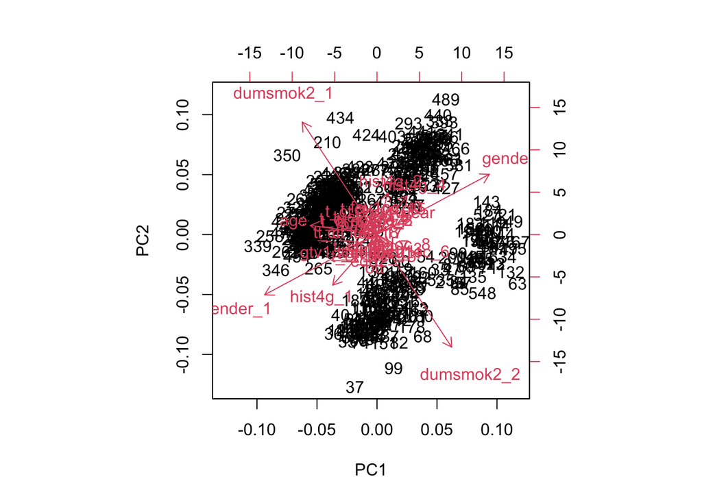

```r
# Plot loadings
biplot(pca_model)
```

To make a final determination on PCA results, the proportion of variance explained by the principal component is calculated.

```r
# Calculate the proportion of variance explained by each principal component
proportion_of_variance <- pca_model$sdev^2 / sum(pca_model$sdev^2)
head(proportion_of_variance)
```

```
## [1] 0.07898491 0.07165834 0.05954603 0.05452137 0.04918236 0.04697745
```

The first principal components captures roughly 7.8% of the total variance in the data. Based on this low value, it is determined not to use the PCA.

## Modeling

Various predictive models are built to classify survival of patients with Stage III Non-Small Cell Lung Cancer. In theory, this could alert physicians to more urgent cases of NSCLC.

### Creation of Logistic Regression Model with Proper Data Encoding

First, a Logistic Regression model is made with the `glm()` function.

```r
# Create logistic regression model
logistic_model <- glm(deadstat ~., data = train_data,
                      family = "binomial", maxit = 1000)
logistic_predictions <- predict(logistic_model,
                                newdata = test_data, type = "response")
```

### Creation of kNN Analysis with Proper Data Encoding

This is followed by the creation of a k-NN analysis with the `knn()` function. It should be noted that there is a question of the appropriateness of the k-NN model considering the data is high dimensional. Throughout the use of the k-NN model, parameter tuning will need to be done to mitigate performance, data structure, and other logistical issues of using k-NN.

```r
# Assign "deadstat" is the target variable
labels_train <- train_data$deadstat
labels_test <- test_data$deadstat

# Exclude labels from the training and testing data
train_data_excluded_labels <- subset(train_data, select = -deadstat)
test_data_excluded_labels <- subset(test_data, select = -deadstat)

# Set seed for reproducibility
set.seed(123)

# Create the k-NN model using knn function
knn_model <- knn(train = train_data_excluded_labels,
                 test = test_data_excluded_labels, cl = labels_train, k = 5)
```

## Evaluation

In working with a complex data set, it is best to not only rely on a reported accuracy value. Precision (positive predictive value) is calculated as the number of true positives divided by the sum of true positives and false positives. Recall (sensitivity) is calculated as the number of true positives divided by the sum of true positives and false negatives. F1 Score is then the mean of precision and recall. An advantage of calculating the F1 score is that small precision or recall will result in lower overall score. The F1 score helps to balance the two. This is then followed with the reported area under the ROC curve (AUC) that adds another metric to suggest whether the classifier has predictive value.

### Evaluation of Fit of Models with Holdout Method

There are various methods outlined below to evaluate the fit of the three models. A confusion matrix compares the accurate predictions versus false predictions. This is then followed by the accuracy, precision, recall, F1 score and AUC.

```r
# Reproducibility
set.seed(123)

# Evaluate the logistic regression model
predicted_log <- ifelse(logistic_predictions > 0.5, "Dead", "Alive")
confusion_matrix_log <- confusionMatrix(test_data$deadstat,
                                        as.factor(predicted_log))
confusion_matrix_log
```

```
## Confusion Matrix and Statistics
##
##           Reference
## Prediction Alive Dead
##      Alive    14    4
##      Dead      5   86
##
##                Accuracy : 0.9174
##                  95% CI : (0.849, 0.9615)
##     No Information Rate : 0.8257
##     P-Value [Acc > NIR] : 0.005012
##
##                   Kappa : 0.7071
##
##  Mcnemar's Test P-Value : 1.000000
##
##             Sensitivity : 0.7368
##             Specificity : 0.9556
##          Pos Pred Value : 0.7778
##          Neg Pred Value : 0.9451
##              Prevalence : 0.1743
##          Detection Rate : 0.1284
##    Detection Prevalence : 0.1651
##       Balanced Accuracy : 0.8462
##
##        'Positive' Class : Alive
##
```

```r
# Extract F1
f1_log <- confusion_matrix_log$byClass["F1"]
f1_log
```

```
##        F1
## 0.7567568
```

```r
# Create a ROC curve
roc_curve_log <- roc(as.numeric(test_data$deadstat == "Dead"),
                     as.numeric(predicted_log == "Dead"))
# Calculate ROC-AUC
roc_auc_log <- auc(roc_curve_log)
roc_auc_log
```

```
## Area under the curve: 0.8614
```

We move on to evaluate the k-NN classifier.

```r
# Create a confusion matrix
confusion_matrix_knn <- confusionMatrix(knn_model, test_data$deadstat)
confusion_matrix_knn
```

```
## Confusion Matrix and Statistics
##
##           Reference
## Prediction Alive Dead
##      Alive     4    1
##      Dead     14   90
##
##                Accuracy : 0.8624
##                  95% CI : (0.7832, 0.9209)
##     No Information Rate : 0.8349
##     P-Value [Acc > NIR] : 0.265148
##
##                   Kappa : 0.2974
##
##  Mcnemar's Test P-Value : 0.001946
##
##             Sensitivity : 0.22222
##             Specificity : 0.98901
##          Pos Pred Value : 0.80000
##          Neg Pred Value : 0.86538
##              Prevalence : 0.16514
##          Detection Rate : 0.03670
##    Detection Prevalence : 0.04587
##       Balanced Accuracy : 0.60562
##
##        'Positive' Class : Alive
##
```

```r
# Extract F1
f1_knn <- confusion_matrix_knn$byClass["F1"]
f1_knn
```

```
##        F1
## 0.3478261
```

```r
# Create a ROC curve for k-NN
roc_curve_knn <- roc(as.numeric(test_data$deadstat == "Dead"),
                     as.numeric(knn_model == "Dead"))

# Calculate ROC-AUC for k-NN
roc_auc_knn <- auc(roc_curve_knn)
roc_auc_knn
```

```
## Area under the curve: 0.6056
```

We continue to move on to the Support Vector Machine model evaluation.

```r
# Create a confusion matrix using caret
confusion_matrix_svm <- confusionMatrix(as.factor(svm_predictions),
                                        as.factor(test_data$deadstat))
confusion_matrix_svm
```

```
## Confusion Matrix and Statistics
##
##           Reference
## Prediction Alive Dead
##      Alive    15    3
##      Dead      3   88
##
##                Accuracy : 0.945
##                  95% CI : (0.884, 0.9795)
##     No Information Rate : 0.8349
##     P-Value [Acc > NIR] : 0.0004774
##
##                   Kappa : 0.8004
##
##  Mcnemar's Test P-Value : 1.0000000
##
##             Sensitivity : 0.8333
##             Specificity : 0.9670
##          Pos Pred Value : 0.8333
##          Neg Pred Value : 0.9670
##              Prevalence : 0.1651
##          Detection Rate : 0.1376
##    Detection Prevalence : 0.1651
##       Balanced Accuracy : 0.9002
##
##        'Positive' Class : Alive
##
```

```r
# Extract F1
f1_svm <- confusion_matrix_svm$byClass["F1"]
f1_svm
```

```
##        F1
## 0.8333333
```

```r
# Calculate ROC-AUC
roc_curve_svm <- roc(as.numeric(test_data$deadstat == "Dead"),
                     as.numeric(svm_predictions == "Dead"))
roc_auc_svm <- auc(roc_curve_svm)
roc_auc_svm
```

```
## Area under the curve: 0.9002
```

### Evaluation with K-Fold Cross-Validation

Instead of evaluating each model based on a split with the previous holdout method, a k-fold Cross Validation is now used. With the k-Fold Cross Validation method,a single parameter called k refers to the number of groups that a given data sample is to be split into. Note the tuning of hyperparameters for each three models.

```r
# Reproducibility
set.seed(123)

# Define cross-validation settings
ctrl <- trainControl(method = "cv", number = 10, # 10-fold cross-validation
                     summaryFunction = twoClassSummary, classProbs = TRUE)

# Train the logistic regression model using k-fold cross-validation
logistic_cv_results <- train(
  deadstat ~ .,
  data = lung,
  method = "glm",
  trControl = ctrl
)
logistic_cv_results
```

```
## Generalized Linear Model
##
## 548 samples
##  39 predictor
##   2 classes: 'Alive', 'Dead'
##
## No pre-processing
## Resampling: Cross-Validated (10 fold)
## Summary of sample sizes: 492, 493, 494, 494, 493, 493, ...
## Resampling results:
##
##   ROC        Sens       Spec
##   0.9181141  0.8066667  0.9496618
```

```r
# Make predictions
predictions_cv_logistic <- predict(logistic_cv_results,
                                   newdata = lung, type = "raw")

# Class labels for the entire data set
actual_labels_logistic <- lung$deadstat

# Make sure both predicted and actual labels are factors with the same levels
predictions_cv_logistic <- factor(predictions_cv_logistic,
                                  levels = levels(actual_labels_logistic))

# Create a confusion matrix for logistic regression
conf_matrix_cv_logistic <- confusionMatrix(predictions_cv_logistic,
                                           actual_labels_logistic)
conf_matrix_cv_logistic
```

```
## Confusion Matrix and Statistics
##
##           Reference
## Prediction Alive Dead
##      Alive    92    0
##      Dead      0  456
##
##                Accuracy : 1
##                  95% CI : (0.9933, 1)
##     No Information Rate : 0.8321
##     P-Value [Acc > NIR] : < 2.2e-16
##
##                   Kappa : 1
##
##  Mcnemar's Test P-Value : NA
##
##             Sensitivity : 1.0000
##             Specificity : 1.0000
##          Pos Pred Value : 1.0000
##          Neg Pred Value : 1.0000
##              Prevalence : 0.1679
##          Detection Rate : 0.1679
##    Detection Prevalence : 0.1679
##       Balanced Accuracy : 1.0000
##
##        'Positive' Class : Alive
##
```

The logistic regression model via the k-Fold Cross Validation shows a high performance with an ROC of 0.918 and recall value of 0.807. What is very surprising is the confusion matrix showing a perfect model with 100% accuracy, recall and precision. All scores overall point to this being a great predictive model.

Below, the k-NN classifier is similarly split.

```r
# Reproducibility
set.seed(123)

# Set control parameter
knn_ctrl <- trainControl(method = "cv", number = 10)

# Define the hyperparameter grid for k-NN
knn_grid <- expand.grid(k = seq(1, 20, by = 1))

# Train the k-NN model using k-fold cross-validation
knn_cv_results <- train(
  deadstat ~.,
  data = lung,
  method = "knn",
  trControl = knn_ctrl,
  tuneLength = 10,
  tuneGrid = knn_grid
)
knn_cv_results
```

```
## k-Nearest Neighbors
##
## 548 samples
##  39 predictor
##   2 classes: 'Alive', 'Dead'
##
## No pre-processing
## Resampling: Cross-Validated (10 fold)
## Summary of sample sizes: 492, 493, 494, 494, 493, 493, ...
## Resampling results across tuning parameters:
##
##   k   Accuracy   Kappa
##    1  0.8066198  0.2564005
##    2  0.8050000  0.2392721
##    3  0.8211003  0.2302339
##    4  0.8137951  0.1918481
##    5  0.8375974  0.2518987
##    6  0.8357792  0.2226300
##    7  0.8411676  0.2477044
##    8  0.8502934  0.2870343
##    9  0.8466246  0.2564233
##   10  0.8412362  0.2276158
##   11  0.8467569  0.2308942
##   12  0.8449387  0.2024113
##   13  0.8485089  0.2221444
##   14  0.8430207  0.1770224
##   15  0.8521789  0.2197135
##   16  0.8466907  0.1846353
##   17  0.8539646  0.2091370
##   18  0.8502621  0.1871625
##   19  0.8467232  0.1429838
##   20  0.8485414  0.1561909
##
## Accuracy was used to select the optimal model using the largest value.
## The final value used for the model was k = 17.
```

```r
# Make predictions on the entire dataset
predictions_cv_knn <- predict(knn_cv_results, newdata = lung)

# Class labels for the entire dataset
actual_labels_knn <- lung$deadstat  # Adjust this based on your actual data

# Create a confusion matrix for k-NN
conf_matrix_cv_knn <- confusionMatrix(predictions_cv_knn, actual_labels_knn)
conf_matrix_cv_knn
```

```
## Confusion Matrix and Statistics
##
##           Reference
## Prediction Alive Dead
##      Alive    18    1
##      Dead     74  455
##
##                Accuracy : 0.8631
##                  95% CI : (0.8315, 0.8908)
##     No Information Rate : 0.8321
##     P-Value [Acc > NIR] : 0.02733
##
##                   Kappa : 0.2831
##
##  Mcnemar's Test P-Value : < 2e-16
##
##             Sensitivity : 0.19565
##             Specificity : 0.99781
##          Pos Pred Value : 0.94737
##          Neg Pred Value : 0.86011
##              Prevalence : 0.16788
##          Detection Rate : 0.03285
##    Detection Prevalence : 0.03467
##       Balanced Accuracy : 0.59673
##
##        'Positive' Class : Alive
##
```

We continue on to the SVM model.

```r
# Train the SVM model using k-fold cross-validation
svm_cv_results <- train(
  deadstat ~.,
  data = lung,
  method = "svmLinear",
  trControl = ctrl,
  metric = "ROC"
)
svm_cv_results
```

```
## Support Vector Machines with Linear Kernel
##
## 548 samples
##  39 predictor
##   2 classes: 'Alive', 'Dead'
##
## No pre-processing
## Resampling: Cross-Validated (10 fold)
## Summary of sample sizes: 494, 493, 493, 492, 493, 493, ...
## Resampling results:
##
##   ROC        Sens       Spec
##   0.9739694  0.7677778  0.971401
##
## Tuning parameter 'C' was held constant at a value of 1
```

```r
# Make predictions
predictions_cv_svm <- predict(svm_cv_results, newdata = lung, type = "raw")

# Use class labels for the entire dataset
actual_labels_cv_svm <- lung$deadstat

# Create a confusion matrix
conf_matrix_cv_svm <- confusionMatrix(predictions_cv_svm, actual_labels_cv_svm)
conf_matrix_cv_svm
```

```
## Confusion Matrix and Statistics
##
##           Reference
## Prediction Alive Dead
##      Alive    87    5
##      Dead      5  451
##
##                Accuracy : 0.9818
##                  95% CI : (0.9667, 0.9912)
##     No Information Rate : 0.8321
##     P-Value [Acc > NIR] : <2e-16
##
##                   Kappa : 0.9347
##
##  Mcnemar's Test P-Value : 1
##
##             Sensitivity : 0.9457
##             Specificity : 0.9890
##          Pos Pred Value : 0.9457
##          Neg Pred Value : 0.9890
##              Prevalence : 0.1679
##          Detection Rate : 0.1588
##    Detection Prevalence : 0.1679
##       Balanced Accuracy : 0.9673
##
##        'Positive' Class : Alive
##
```

### Comparison of Models and Interpretation

An ANOVA (Analysis of Variance) test is used to determine the difference in means among different models. The residuals of each model are calculated and combined to conduct an ANOVA test. In summary, the ANOVA results suggest that at least one of the models has a significantly different mean compared to the others. Therefore a Tukey’s Honestly Significant Difference (HSD) test is done to determine which models is significantly different from the rest.

```r
# Residuals of logistic regression model
residuals_log <- as.numeric(test_data$deadstat == "Dead") -
  as.numeric(predicted_log == "Dead")
# Residuals of k-NN model
residuals_knn <- as.numeric(test_data$deadstat == "Dead") -
  as.numeric(knn_model == "Dead")
# Residuals of SVM model
residuals_svm <- as.numeric(test_data$deadstat == "Dead") -
  as.numeric(svm_predictions == "Dead")

# Combine residuals into a data frame
residuals_df <- data.frame(
  Model = rep(c("Logistic Regression", "k-NN", "Support Vector Machine"),
              each = nrow(test_data)),
  Residuals = c(residuals_log, residuals_knn, residuals_svm)
)

# Fit a linear model and conduct ANOVA
anova_model <- aov(Residuals ~ Model, data = residuals_df)
summary(anova_model)
```

```
##              Df Sum Sq Mean Sq F value  Pr(>F)
## Model         2  1.119  0.5596   6.375 0.00192 **
## Residuals   324 28.440  0.0878
## ---
## Signif. codes:  0 '***' 0.001 '**' 0.01 '*' 0.05 '.' 0.1 ' ' 1
```

```r
# Perform Tukey's HSD test
tukey_results <- TukeyHSD(anova_model)
tukey_results
```

```
##   Tukey multiple comparisons of means
##     95% family-wise confidence level
##
## Fit: aov(formula = Residuals ~ Model, data = residuals_df)
##
## $Model
##                                                    diff         lwr        upr
## Logistic Regression-k-NN                    0.128440367  0.03394683 0.22293391
## Support Vector Machine-k-NN                 0.119266055  0.02477252 0.21375959
## Support Vector Machine-Logistic Regression -0.009174312 -0.10366785 0.08531923
##                                                p adj
## Logistic Regression-k-NN                   0.0042931
## Support Vector Machine-k-NN                0.0089081
## Support Vector Machine-Logistic Regression 0.9716053
```

## Deployment

### Use of Bagging with Homogenous Learners

Bagging generates a number of training data sets through bootstrap sampling the original training data. These data sets are then used to create a set of models using the learned algorithm. In the case of classification models, the predictions are then combined using voting to reduce overfitting.

```r
# Set seed for reproducibility
set.seed(123)

# Apply bagging to logistic regression
logistic_bagging <- bagging(deadstat ~ ., data = lung,
                            nbagg = 25, fit = logistic_model)

# Make predictions on the entire data set
predictions_bagging_logistic <- predict(logistic_bagging, newdata = lung)

# Evaluate the performance of bagged logistic regression
conf_matrix_bagging_logistic <- confusionMatrix(predictions_bagging_logistic,
                                                lung$deadstat)
conf_matrix_bagging_logistic
```

```
## Confusion Matrix and Statistics
##
##           Reference
## Prediction Alive Dead
##      Alive    92    1
##      Dead      0  455
##
##                Accuracy : 0.9982
##                  95% CI : (0.9899, 1)
##     No Information Rate : 0.8321
##     P-Value [Acc > NIR] : <2e-16
##
##                   Kappa : 0.9935
##
##  Mcnemar's Test P-Value : 1
##
##             Sensitivity : 1.0000
##             Specificity : 0.9978
##          Pos Pred Value : 0.9892
##          Neg Pred Value : 1.0000
##              Prevalence : 0.1679
##          Detection Rate : 0.1679
##    Detection Prevalence : 0.1697
##       Balanced Accuracy : 0.9989
##
##        'Positive' Class : Alive
##
```

Above, a 99.8% accuracy is achieved, 100% recall, and 98.9% precision showing a very high performing model. In practical terms, the confusion matrix shows only one instance of a patient given a wrong prediction. In other words, 0.18% of the predictions were wrong. Again, this shows to be a well predictive model.

```r
# Set seed for reproducibility
set.seed(123)

# Apply bagging to k-NN model
knn_bagging <- bagging(deadstat ~ ., data = lung,
                            nbagg = 25, fit = knn_model)

# Make predictions on the entire data set
predictions_bagging_knn <- predict(knn_bagging, newdata = lung)

# Evaluate the performance of bagged k-NN model
conf_matrix_bagging_knn <- confusionMatrix(predictions_bagging_knn,
                                                lung$deadstat)
conf_matrix_bagging_knn
```

```
## Confusion Matrix and Statistics
##
##           Reference
## Prediction Alive Dead
##      Alive    92    1
##      Dead      0  455
##
##                Accuracy : 0.9982
##                  95% CI : (0.9899, 1)
##     No Information Rate : 0.8321
##     P-Value [Acc > NIR] : <2e-16
##
##                   Kappa : 0.9935
##
##  Mcnemar's Test P-Value : 1
##
##             Sensitivity : 1.0000
##             Specificity : 0.9978
##          Pos Pred Value : 0.9892
##          Neg Pred Value : 1.0000
##              Prevalence : 0.1679
##          Detection Rate : 0.1679
##    Detection Prevalence : 0.1697
##       Balanced Accuracy : 0.9989
##
##        'Positive' Class : Alive
##
```

The exact same performance metrics are achieved with the k-NN bagging as with the Logistic Regression bagging, showing another great performing model.

```r
# Set seed for reproducibility
set.seed(123)

# Apply bagging to k-NN model
svm_bagging <- bagging(deadstat ~ ., data = lung,
                            nbagg = 25, fit = svm_model)

# Make predictions on the entire data set
predictions_bagging_svm <- predict(svm_bagging, newdata = lung)

# Evaluate the performance of bagged k-NN model
conf_matrix_bagging_svm <- confusionMatrix(predictions_bagging_svm,
                                                lung$deadstat)
conf_matrix_bagging_svm
```

```
## Confusion Matrix and Statistics
##
##           Reference
## Prediction Alive Dead
##      Alive    92    1
##      Dead      0  455
##
##                Accuracy : 0.9982
##                  95% CI : (0.9899, 1)
##     No Information Rate : 0.8321
##     P-Value [Acc > NIR] : <2e-16
##
##                   Kappa : 0.9935
##
##  Mcnemar's Test P-Value : 1
##
##             Sensitivity : 1.0000
##             Specificity : 0.9978
##          Pos Pred Value : 0.9892
##          Neg Pred Value : 1.0000
##              Prevalence : 0.1679
##          Detection Rate : 0.1679
##    Detection Prevalence : 0.1697
##       Balanced Accuracy : 0.9989
##
##        'Positive' Class : Alive
##
```

Interestingly enough, the same high performance metrics are achieved for all three logistic, k-NN, and SVM models. Note that bagging is best for models that are sensitive to changes in training data. In theory, this would include the SVM model.

### Construction of Ensemble Model as a Function

A function is now created to provide a stacked ensemble with logistic regression, k-NN, and SVM as base models and logistic regression as the top layer model. The process behind this function is found at: https://www.analyticsvidhya.com/blog/2017/02/introduction-to-ensembling-along-with-implementation-in-r/

```r
# Function to construct a stacked ensemble
ensembleFunc <- function(train_data, test_data, outcome_name) {
  # Step 1: Train individual base layer models
  fitControl <- trainControl(
    method = "cv",
    number = 10,
    savePredictions = 'final',
    classProbs = TRUE
  )

  predictors <- names(train_data)[!names(train_data) %in% outcome_name]

  model_lr <- train(train_data[, predictors], train_data[, outcome_name],
                    method = 'glm', trControl = fitControl, tuneLength = 3,
                    maxit = 1000)
  model_knn <- train(train_data[, predictors], train_data[, outcome_name],
                     method = 'knn', trControl = fitControl, tuneLength = 3)
  model_svm <- train(train_data[, predictors], train_data[, outcome_name],
                     method = 'svmLinear', trControl = fitControl, tuneLength = 3)

  # Step 2: Predict using each base layer model for training data and test data
  train_data$OOF_pred_lr <- model_lr$pred$Y[order(model_lr$pred$rowIndex)]
  train_data$OOF_pred_knn <- model_knn$pred$Y[order(model_knn$pred$rowIndex)]
  train_data$OOF_pred_svm <- model_svm$pred$Y[order(model_svm$pred$rowIndex)]

  test_data$OOF_pred_lr <- predict(model_lr, test_data[predictors],
                                   type = 'prob')$Y
  test_data$OOF_pred_knn <- predict(model_knn, test_data[predictors],
                                    type = 'prob')$Y
  test_data$OOF_pred_svm <- predict(model_svm, test_data[predictors],
                                    type = 'prob')$Y

  # Step 3: Train the top layer model (logistic regression) on bottom
  predictors_top <- c('OOF_pred_lr', 'OOF_pred_knn', 'OOF_pred_svm')

  top_layer_model_fit <- train(train_data[, predictors_top],
                               train_data[, outcome_name], method = 'glm',
                               trControl = fitControl, tuneLength = 3,
                               maxit = 1000)

  # Step 4: Predict using the top layer with the predictions of bottom layer
  test_data$stacked_predictions <- predict(top_layer_model_fit,
                                           test_data[, predictors_top],
                                           type = 'prob')$Y

  return(test_data$stacked_predictions)
}
```